# Complejos industriales regionales en Mexico

Jaime A. Prudencio-Vázquez

2023-02-08

# Introduccion

La industria, particularmente la manufactura, ha jugado un papel central en el proceso de crecimiento y desarrollo histórico de las economías nacionales, aunque no sin llevar aparejado un sinnúmero de contradicciones. Esto se explica por el incremento en la productividad del trabajo y las ventajas derivadas de los efectos de arrastre de los encadenamientos productivos que son más intensos en la industria que en los servicios o la agricultura (Szirmai, 2012).

Durante el periodo sustitutivo de importaciones en México, la política industrial basada en la premisa del binomio industrialización y desarrollo fue impulsada a través de medidas activas de intervención y financiamiento al sector industrial (Cordera and Orive, 1981). No obstante, con el ascenso del neoliberalismo, el pensamiento económico dominante tornó la política económica indiferente al sector de actividad, considerando que la promoción de las finanzas, los servicios o la industria era equivalente en términos de sus resultados para el crecimiento (Palma, 2005). En México, con el arribo del proceso de apertura económica que inició en los ochenta y que se coronó con la firma del Tratado de Libre Comercio de América del Norte (TLCAN), la política industrial sectorial, si bien en el discurso seguía existiendo, se había estrechado de manera considerable hasta hacerla inexistente en la práctica debido a su comparativamente reducido presupuesto y lo limitado de sus alcances (Moreno-Brid and Ros-Bosch, 2018).

De forma relativamente reciente ha resurgido el interés teórico y político por el carácter central de la actividad industrial en el desarrollo. En la Agenda del Desarrollo 2015, la Organización de las Naciones Unidas ha reconsiderado el papel de la industria en el proceso de crecimiento y desarrollo (Trejo, 2017). Esto se ha traducido en acciones como la emprendida por el Gobierno de México en septiembre de 2022 a través de la Secretaría de Economía que anunció una serie de lineamientos que buscan recuperar la política industrial como herramienta de promoción del crecimiento y desarrollo económico (Secretaría_de_Economía, 2022).

Sin embargo, tanto la política industrial de la época del sustitutivo de importaciones como los intentos más recientes por recuperar este instrumento de intervención en América Latina siguen siendo de carácter fundamentalmente macroeconómico pues se dirigen a sectores específicos considerados clave sin distinguir las especificidades socioterritoriales de las regiones donde se suceden dichas actividades (Gallagher et al., 2008; Villarreal et al., 2017). Además, estas medidas no suelen considerar las posibles ventajas derivadas de la concentración territorial de industria que se presentan a través de las economías de aglomeración, es decir, las medidas de política industrial tradicionales son “espacialmente ciegas” (Fothergill et al., 2019).

Existe pues la necesidad de hacer explícito dentro de la política industrial la heterogeneidad y disimilitudes regionales que caracterizan a las economías en desarrollo como México. Más aún, dicha política industrial debe nutrirse de la discusión basada en la evidencia de los vínculos materiales de interrelación sectorial proporcionados por la matriz de insumo producto que permitan identificar en el territorio complejos industriales susceptibles de generar crecimiento y, potencialmente, desarrollo.

El objetivo de este estudio es doble. Por un lado se busca identificar actividades industriales estrechamente vinculadas a partir de sus interrelaciones materiales dadas por la matriz de insumo producto, es decir, cadenas productivas industriales. Por otro lado, se pretende encontrar en el territorio nacional dichas cadenas a partir de sus patrones de concentración espacial, o sea, ubicar complejos industriales que puedan ser incorporados en estrategias de política industrial que hagan explícitas las características socioterritoriales de los espacios donde se asientan.

En la siguiente sección de este documento se lleva a cabo una revisión de literatura teórica y empírica sobre concentraciones espaciales de actividad económica y las fuerzas que emergen de ellas bajo la forma de economías de aglomeración. En seguida, se apunta el método usado para la identificación de cadenas productivas y su regionalización como complejos industriales. Luego, se presentan los resultados de la identificación de cadenas productivas y su distribución territorial a nivel municipal en México, donde también se presentan las conclusiones y reflexiones finales derivadas de los resultados.

# 1. Economías de aglomeración y concentraciones territoriales de actividad económica

Un tema central en las disciplinas regionales ha sido el conjunto de fuerzas que dan forma al espacio económico (Fischer and Nijkamp, 2014). Dichas fuerzas, las economías de aglomeración, están vinculadas a las ventajas que gozan las unidades económicas que presentan un patrón espacialmente concentrado (Gordon and McCann, 2000: 516). Las ventajas emergen del carácter social y cooperativo del proceso de producción (Marx, 2011, pp. 391–408) y de la división social del trabajo (Scott, 2006). Ambos elementos se traducen en un mejor desempeño de las unidades económicas a través de un incremento de la productividad del trabajo y la reducción de costos (Cohen and Paul, 2009). Usualmente, las economías de aglomeración son divididas en dos tipos: i) economías de especialización o economías tipo Marshall-Arrow-Romer (MAR) que se refieren a la aglomeración de empresas que pertenecen a la misma industria (Glaeser et al., 1992; Sjöholm, 1999: 560) y ii) economías de urbanización o economías tipo Jacobs en las que no es la especialización sino la diversidad y variedad de actividades económicas concentradas geográficamente la que puede promover innovación y crecimiento (Duranton, 2014; Oort and Lambooy, 2014).

Las economías de aglomeración configuran cierto tipo de patrón de distribución espacial, que pueden ser caracterizdos como patrones de concentración de la actividad económica. Estos patrones han recibido diferentes denominaciones: distritos industriales, complejos industriales, polos industriales, sistemas productivos regionales, sistemas regionales de innovación, clústeres, entre otros. Esta variedad conceptual puede causar a veces confusión debido a que dichos términos se usan frecuentemente de forma indiscriminada y a veces sin una reflexión crítica sobre su alcance teórico o empírico. Una mínima observación respecto al contenido de dichos términos es necesaria, más aún cuando de lo que se trata de es identificar dichas aglomeraciones con el objetivo de impulsar su crecimiento a través de política industrial. En esta sección se proponen tres criterios que pueden contribuir a mejor comprender y distinguir entre los múltiples conceptos existentes relacionados con los patrones de concentración territorial de actividad económica, tales son: i) fase del desarrollo capitalista en el cual fueron acuñados, ii) el tipo de empresas que están vinculada a la concentración y iii) extensión de la realidad social que busca ser capturada con el concepto.

El primer criterio, la fase de desarrollo del sistema capitalista en el cual el término fue propuesto, es un criterio de tipo histórico. Los diversos conceptos que describen los patrones de concentración de actividad económica fueron creados al menos en periodo de un siglo de diferencia, por lo que los cambios en la organización del proceso de trabajo debido al progreso técnico, el uso de nuevas fuentes de energía y los principios de administración del trabajo afectan las fuerzas que causan dichos patrones y la forma específica que estos pueden asumir. Más aún, la forma misma del sistema capitalista ha cambiado considerablemente en dicho lapso: de una fase de competencia centrada en mercados locales, a una estructura oligopólica de empresas multinacionales que abastecen mercados nacionales y, actualmente, a una red global de proveedores de bienes gobernada por empresas multinacionales a través de las cadenas globales de valor.

El primer criterio advierte sobre la historicidad de los conceptos. Por ejemplo, el término distrito industrial fue propuesto por Marshall a principios del siglo XX para referir un tipo de sociedad que estaba en extinción: la pequeña manufactura centrada en la proveeduría de mercados locales (Trippl and Bergman, 2021: 450). Este término, cuando es rescatado por los neo-marshallianos en la década de los setenta del siglo XX, refiere un sistema de producción semi-capitalista o de pequeña producción mercantil en la que la autoridad del artesano y la tradición local es relevante. La atención a las variables sociales, institucionales y culturales dada por los neo-marshallianos y su énfasis en las pequeñas y medianas empresas recuerda, en alguna medida, a la era del capitalismo competitivo.

El segundo criterio es uno estructura: el tipo de empresas que están envueltas en la aglomeración. El concepto elegido para referir los patrones de concentración de actividad económica debe de tomar en consideración si la aglomeración está estructurada por pequeñas, medianas o, incluso, por empresas multinacionales. Este criterio pone de relieve la distinción de si la estructura de la empresa tiene una administración familiar o corporativa; o si acaso tiene una estructura familiar, qué generación de propietarios la dirige. Por ejemplo, el concepto de clúster de Porter se aproxima más al análisis de la empresa multinacional en comparación con el de sistema productivo local que usualmente describe una estructura de pequeñas y medianas empresas. Además, esta distinción atañe no sólo al tamaño de la empresa sino también al origen de su capital, esto en la medida en que los intereses de los propietarios de la empresa sobre el desarrollo de la región pueden variar ampliamente si la empresa está estructurada fundamentalmente de capital nacional o multinacional.

Finalmente, el tercer criterio es de carácter analítico o delimitativo y se refiere a la extensión de la realidad social que busca ser capturada a través de las herramientas conceptuales. Algunos de los conceptos asociados a los patrones de concentración de actividad económica son más estrechos que otros. Esto es porque centran su atención sólo en aspectos económicos de la realidad, como los vínculos insumo-producto, la estructura de costos o los incrementos en la productividad, tal y como lo hace el concepto de complejo industrial o el de distrito industrial en el sentido original dado por Marshall. Algunos otros son más abarcativos y capturan no sólo los aspectos económicos, sino rasgos socio-culturales e incluso factores institucionales, tal y como lo hace el concepto de *innovative milleaux* o el de sistemas regionales de innovación.

En las siguientes líneas, son discutidos los conceptos más comunes usados para describir los patrones de concentración de actividad económica, a la luz de las ideas previas. De forma específica, los conceptos tratados son: distrito industrial (marshalliano y neo-marshalliano), *innovative milieux*, polos de crecimiento, clúster industrial, sistema de producción territorial, complejo industrial y clúster. Esta distinción y contraste permite no sólo seleccionar críticamente el concepto utilizado en este trabajo, complejo industrial, sino justificar la selección de la técnica para la identificación de dichos complejos.

# 2. Conceptos sobre patrones de concentración de actividad económica

Como es sabido, Marshall (1957) apunta las causas y consecuencias de las aglomeraciones de actividad económica a través del término distritos industriales. Él vincula dichos patrones a tres fuerzas: i) transmisión de conocimiento (métodos y técnicas de producción u organización del proceso de trabajo), ii) desarrollo de unidades económicas especializadas que suministran insumos y iii) mano de obra calificada y especializada. El contenido del concepto propuesto por Marshall describe las reminiscencias de la fase competitiva del capitalismo en el que las pequeñas y medianas empresas cercanas en el espacio adquieren ventajas como resultado de las economías de aglomeración. La emergencia de estas ventajas les permite, bajo determinadas circunstancias, competir con las grandes empresas dominantes en un sector.

En este sentido, “el distrito marshalliano estaba esencialmente limitado a distancias que podrían ser económicamente cubiertas de forma cotidiana por trabajadores y proveedores hacia finales del siglo XIX, las densidades eran lo suficientemente elevadas y las distancias suficientemente cortas como para que los distritos fueran descritos como ‘vecindarios’ (Trippl and Bergman, 2021: 449-450). Así, el concepto marshalliano de distrito industrial se refiere predominantemente a la fase del capitalismo de libre competencia, ya en extinción incluso en los años en que fueron publicados los”Principios” de Marshall, y enfatiza los aspectos económicos del fenómeno de concentración espacial a la vez que centra su atención en las pequeñas y medianas empresas.

Durante la era dorada del capitalismo, tras la segunda guerra mundial y antes de la crisis de los precios del petróleo en los setenta, hubo varios intentos de teorizar sobre el proceso de desarrollo desde una perspectiva regional centrada a veces en las economías atrasadas. Entre ellos destaca la contribución de Perroux a través de la teoría de los polos de desarrollo. En ella, las medidas de política económica consistían en incentivos fiscales dirigidos a grandes empresas manufactureras, usualmente multinacionales, con la idea de reproducir la senda y condiciones de desarrollo experimentado por las regiones previamente desarrolladas de los países capitalistas (Garofoli, 2020: 199).

El concepto de polos de crecimiento del teórico francés es coincidente con la fase oligopólica del desarrollo capitalista de la posguerra, en el que la gran empresa multinacional opera como proveedora de mercados nacionales y esta vinculada, de forma más o menos fuerte, a las pequeñas y medianas empresas nacionales mediante encadenamientos productivos. Dentro de la concepción de Perroux, los factores económicos de la aglomeración son centrales, por lo que prestó poca atención a los aspectos institucionales, sociales y culturales que incidían sobre la dinámica del polo.

Ya en la década de los setenta, en medio de la crisis generalizada que marcó el tránsito hacia la producción geográficamente fragmentada como forma dominante de producción, algunas pequeñas y medianas empresas en el norte de Italia encontraron la manera de sobrevivir tomando ventaja no sólo de la proximidad geográfica sino también a través de múltiples aspectos sociales y culturales que distinguían la actividad productiva de la región. Los estudios de Becattini (1979, citado por Tripply Bergman, 2014) así como sus contribuciones sobre las causas del éxito de la llamada Tercera Italia, le permitieron acuñar el concepto de distritos industriales neo-marshallianos. En este concepto los factores económicos son relevantes, pero están lejos de ser los únicos determinantes del éxito en el proceso de crecimiento regional. Becattini describe su concepto como “un arreglo socioeconómico complejo que resalta la relación entre eficiencia, competitividad en la producción y las condiciones socioculturales prevalecientes a nivel regional (Trippl and Bergman, 2021: 444).

Aproximadamente en los mismos años, emerge otro concepto particularmente difundido entre los francófonos, que es usado para describir a las regiones capaces de promover crecimiento basado en innovación: *Milieux Innovateurs*, que puede ser traducido como “entornos innovadores”. Este concepto es a veces usado de forma intercambiable con el concepto de *red* (Gallaud, 2013). Trippl y Bergman (2021: 444) definen a los entornos innovadores “como un conjunto de reglas, prácticas e instituciones específicas de la región que mejora la capacidad de los actores regionales para innovar y coordinarse con otros actores innovadores”. De forma semejante al concepto anterior, los entornos innovadores no centran su atención en los aspectos económicos y más bien destacan aspectos socioinstitucionales que pueden incidir en los procesos de innovación. Un concepto próximo a éste es el *sistema de producción territorial*, que puede ser concebido como un intento de comprender mejor los aspectos territoriales del proceso de innovación, no obstante, el alcance de dicho concepto es mucho menos nítido (Crevoisier y Maillat, 1991; citado por Trippl y Bergman, 2014: 446)

Los conceptos anteriores, tanto el distrito industrial neomarshalliano, el entorno innovador y el sistema de producción territorial, emergen en la fase de transición del oligopolio, organizado a través de los procesos fordistas y tayloristas de producción, hacia la fase de mercados abiertos globalmente y conectados a través de cadenas productivas espacialmente fragmentadas en donde los sistemas de producción flexible juegan un papel relevante. Además, estos conceptos prestan mucha mayor atención a los factores sociales, institucionales y culturales que pueden impulsar o condicionar el éxito económico de las pequeñas y medianas empresas, vinculadas a las multinacionales que comandan la cadena de producción.

Probablemente el concepto más popular que busca describir los patrones de concentración espacial de la actividad económica es el término clúster. Éste se populariza en la última década del siglo XX gracias a los trabajos de Porter sobre estrategias corporativas. Este concepto se refiere a empresas multinacionales y presta mucha mayor atención a los aspectos de competencia entre los actores que integran el llamado clúster y deja en segundo término la posibilidad de cooperación entre las empresas que lo integran que, si bien puede existir, más bien es un rasgo secundario o derivado. Un clúster puede ser definido como “concentraciones geográficas de empresas interconectadas, proveedores especializados, proveedores de servicios, empresas en industrias relacionadas e instituciones asociadas en campos particulares que compiten pero también cooperan” (Porter 1998, citado por Trippl y Bergman 2014: 447). No obstante, el concepto ha recibido múltiples críticas debido a su ambigüedad y a su falta de precisión sobre sus límites geográficos y sectoriales, además de la poca atención prestada a los factores sociales (Martin and Sunley, 2003; Pacheco-Vega, 2007).

Otro concepto que suele ser usado en los estudios de economía urbana es el de complejo industrial (Villarreal et al., 2017), que “son caracterizados por conjuntos de relaciones identificables y estables entre empresas que se manifiestan en parte en su comportamiento espacial. Las relaciones se conciben principalmente en términos de vínculos comerciales, y son estos patrones de ventas y compras los que rigen principalmente su comportamiento de ubicación” (Gordon and McCann, 2000: 518). Este concepto emerge aproximadamente en la misma fase de transición, pero a diferencia de los otros, centra su atención de forma mucho más notable en los factores económicos dados por aspectos materiales cuantificables, es decir, en las relaciones insumo producto, por lo que los aspectos sociales o institucionales no figuran en su alcance, pero tampoco distingue entre el tipo de empresas que en él participan.

La breve enumeración que se ha hecho sobre algunos de los términos usados para describir los patrones espaciales de concentración de la actividad económica está, por supuesto, lejos de ser exhaustiva. No obstante, a la luz de los criterios apuntados, es posible ubicarlos históricamente y distinguir los aspectos de la realidad que buscan captar. El concepto de complejo industrial, que se centra sólo en las interrelaciones materiales entre unidades económicas dadas por los vínculos insumo-producto y que no distingue entre la estructura de las empresas, es el que guiará el resto del trabajo y que, como se verá en la sección 4, se corresponde con el alcance del método propuesto para la identificación de dichos complejos.

# 3. El estudio de las concentraciones espaciales de actividad económica en México

En nuestro país, el interés por el estudio de las aglomeraciones de actividad económica no es nuevo; sin embargo, la distinción crítica de la categoría que describe los patrones de concentración territorial de la actividad económica no es lo usual. En esta sección presentamos algunos de los trabajos más recientes que, para el caso de la economía mexicana, buscan identificar concentraciones territoriales de actividad económica.

Algunos de los estudios para México se centran en los cambios en los patrones de localización que trajo consigo el proceso de apertura económica (Gómez-Zaldívar et al., 2017; Trejo-Nieto, 2013) o la integración económica que ésta causó (Flores, 2008). Otros se enfocan en el estudio de agrupaciones de sectores concretos, donde se indagan las causas de su origen, como el caso de la agrupación de la industria aeroespacial en Querétaro (Burgos and Johnson, 2018), o bien, llevan a cabo un contraste de las características específicas de un agrupamiento, como el del calzado (López-Hernández, 2018), con las características canónicas de los agrupamientos desde cierta perspectiva teórica (Rabellotti, 1995); en tanto, otros trabajos evalúan el desempeño de las agrupaciones presentes en regiones específicas (Jiménez-Almaguer et al., 2013).

Otros trabajos se han concentrado en los métodos de delimitación e identificación de tales agrupamientos en el territorio nacional, para luego indagar sobre su desempeño. Los trabajos de García y Carranco (2008) y García et al. (2009) parten de la definición de lo que ellas llaman agrupamiento productivo local y proponen un sencillo método para su identificación y evaluación. Por su parte, Mendoza-Velázquez (2017) recurre a la propuesta de Porter (1998, 2003, citados por Mendoza-Velázquez 2017) para definir agrupaciones a las que denomina clústers.

En relación con la identificación de complejos industriales, aunque no siempre sean denominados así, se encuentran los trabajos de Laguna-Reyes (2010), González et al. (2017) y Trejo y Negrete (2018b). En ellos, se busca identificar agrupaciones en el territorio nacional basadas en el interrelacionamiento dado por los vínculos insumo-producto, basados en el método de análisis de conglomerados desarrollado por Feser y Bergman (2000a).

El trabajo de Laguna Reyes (2010: 199) “analiza y aplica una metodología para identificar las cadenas productivas, como referencia para el análisis de la base económica de los clusters industriales regionales” (p. 119). El autor concibe a las agrupaciones, a las que llama clústeres, como “concentraciones de compañías e instituciones interconectadas en un campo en particular, que compiten y cooperan” (p. 119), aunque reconoce que no existe una definición plenamente clara sobre el sentido de cluster industrial, por lo que, para su identificación, él se basa en los aspectos puramente económicos al señalar que dichos agrupamientos son “un conjunto de sectores que usan cantidades relativamente grandes de los productos de los demás sectores” (p. 123), en este sentido, lo que el autor termina identificando son, justamente, complejos industriales, en el sentido apuntado en la sección previa.

Por su parte, Trejo y Negrete (2018b) se plantean tres objetivos: i) revisar la estructura económica, desempeño y cambios de la región centro de México (RECEMEX), ii) identificar los sectores económicos más relevantes de la región a través de la estimación de una matriz de insumo producto regional e identificar los clústeres presentes en esta región y iii) establecer el desempeño de dichas agrupaciones. Respecto al punto ii, echan mano del método de Feser y Bergman (2000) con el que “logran la identificación de seis clusters en la economía de la RECEMEX, que agrupan a 21 de los 28 sectores” (p. 24).

El estudio de González Villareal (Villarreal et al., 2017) se plantea identificar en México complejos industriales con el propósito de proporcionar ideas de política económica para dichos espacios de concentración en el contexto de la especialización inteligente y la variedad relacionada, medidas inspiradas en las estrategias de política regional de la Unión Europea (Balland et al., 2019; Frenken et al., 2007). Entre los resultados a los que los autores llegan se encuentra la identificación de 5 cadenas productivas: manufactura de componentes electrónicos, automóviles, químicos, textiles y prendas de vestir y productos agrícolas y alimentos procesados, así como su distribución a nivel municipal en México.

En la siguiente sección se presenta la metodología para la identificación de complejos industriales que, a partir de los trabajos de Feser y Bergman (2000) y de Feser et al. (2005), busca distinguir y clasificar con mayor precisión las concencraciones territoriales de actividad económica en los municipios de México.

# 4. Identificación de patrones de aglomeración de la actividad económica

Los métodos para la identificación de patrones de aglomeración de la actividad económica son variados. Múltiples estudios en economía regional utilizan medidas de aglomeración o especialización para su identificación (Castro and Gallardo, 2008; Komorowski, 2020; Kopczewska et al., 2017; O’Donoghue and Gleave, 2004), o bien llevan a cabo estudios de caso desde la perspectiva de gestión de la empresa (Tvaronavičienė et al., 2015). No obstante, desde un punto de vista puramente técnico, la delimitación de concentraciones de actividad se puede reducir a la identificación de patrones, lo que permite echar mano de métodos computacionales tales como el análisis de agrupamientos (Adolfsson et al., 2019).

Si bien se piensa, la matriz de insumo-producto puede ser vista como un instrumento que muestra la cercanía o semejanza entre los elementos que la componen, en este caso actividades económicas: entre más relación haya entre sectores económicos a través de sus vínculos dados por las compras y ventas, más “cercanos” serán e integrarán un agrupamientos de actividad o cadenas productivas. A partir de esta idea, la “cercanía” entre sectores puede ser analizada a través de múltiples métodos computacionales, como por ejemplo: la teoría de grafos, teoría de redes, métodos de triangulación o análisis factorial a través de componentes principales.

Múltiples estudios utilizan métodos basados en la identificación de vínculos insumo-producto en una economía nacional y la mayor parte de ellos se sirve del trabajo de Feser y Bergman (Delgado et al., 2016; Feser et al., 2005; 2000b; Laguna-Reyes, 2010; Nieto and Negrete, 2018a; Sonis et al., 2008; Villarreal et al., 2017). En este trabajo, se propone un enfoque basado en la clásica propuesta de Feser y Bergman (2000b) y Feser et al. (2005) para la identificación de cadenas productivas y su espacialización, es decir, para la identificación de complejos industriales.

El método propuesto en este trabajo se divide en dos grandes pasos: primero se lleva a cabo la identificación de conjuntos de actividades económicas fuertemente interrelacionadas a través de sus vínculos insumo-producto, es decir, primero se identifican cadenas productivas dadas por patrones de compras y ventas a nivel del conjunto de la economía. Luego, las cadenas productivas son ubicadas en el espacio geográfico nacional a nivel municipal a través del reconocimiento de patrones de interacción espacial en el empleo de dichas cadenas.

## 4.1 Identificación de las cadenas productivas

La matriz de insumo producto (MIP) es un instrumento que permite conocer las relaciones intersectoriales entre las actividades económicas que se desarrollan en una economía nacional a través del registro de las compras y ventas que se suceden entre ellas (INEGI, 2018a). La MIP proporciona el valor monetario de los bienes vendidos por la actividad de la fila $i$ a la actividad de la columna $j$, $a_{ij}$, es decir, las ventas que realiza el sector $i$ al sector $j$. Sea $p$ y $s$ el valor del total de compras intermedias y total de ventas intermedias, respectivamente; así, la relación entre cada par de actividades, $i$ y $j$ se puede caracterizar a partir de los siguientes coeficientes (Feser and Bergman, 2000a, p. 6):

$$x_{ij}=\frac{a_{ij}}{p_j};
x_{ji}=\frac{a_{ji}}{p_i};
y_{ij}=\frac{a_{ij}}{s_j};
y_{ji}=\frac{a_{ji}}{s_i}$$

A la letra, Feser y Bergman (2000: 5) explican de este modo los coeficientes anteriores:

“$x_{ij};x_{ji}$: compras de bienes intermedios hechos por $j$ ($i$) a $i$ ($j$) como proporción del total de compras de bienes intermedios de $j$ ($i$). Un valor alto de $x_{ij}$, por ejemplo, sugiere que la industria $j$ depende de la industria $i$ como una fuente de una gran proporción del total de sus insumos intermedios.

$y_{ij}; y_{ji}$: ventas de bienes intermedios de $i$ ($j$) a $j$ ($i$) como una proporción de las ventas totales de bienes intermedios de $i$ ($j$). Un valor alto de $y_{ij}$, por ejemplo, sugeriría que $i$ depende de la industria $j$ como mercado para una gran proporción de sus ventas totales de bienes intermedios”.

Los coeficientes anteriores se pueden sintetizar en dos matrices: $X$ y $Y$, llamadas matriz de proporciones de compras y matriz de proporciones de ventas, respectivamente. Sobre las matrices $X$ y $Y$ se desarrolla un análisis de correlación que consiste en construir cuatro matrices cuyos elementos corresponden al grado de asociación entre pares de actividades, digamos $l$ y $m$. De nuevo siguiendo a la letra a Feser y Bergman (2000: 5):

“$r(x_l\cdot x_m)$: mide el grado en que las industrias $l$ y $m$ tienen patrones similares de compra de insumos.

$r(y_l\cdot y_m)$: mide el grado en que la industrias $l$ y $m$ presentan patrones de venta de productos similares, es decir, el grado en que venden bienes a una combinación similar de compradores de insumos intermedios.

$r(x_l\cdot y_m)$: mide el grado en que el patrón de compra de la industria $l$ es similar al patrón de venta de la industria $m$, es decir, el grado en que la industria $l$ compra insumos de industrias a las que $m$ suministra.

$r(y_l\cdot x_m)$: mide el grado en que el patrón de compra de la industria $m$ es similar al patrón de venta de la industria $l$, es decir, el grado en que la industria $m$ compra insumos de las industrias a las que $l$ suministra”.

Posteriormente, con las cuatro matrices obtenidas, se construye otra que contiene sólo los coeficientes de correlación más altos entre pares de actividades, dicha matriz “muestra las interrelaciones más importantes entre pares de industrias económicas” (Villarreal et al., 2017: 5), es decir, sintetiza los patrones de compras y ventas más intensos entre cada par de sectores.

Finalmente, para obtener los conjuntos de actividades que integran las cadenas productivas, se recurre al Análisis de Componentes Principales (PCA) sobre ésta última matriz. En esencia, el análisis de componentes principales, una de las técnicas de estadística multivariada más socorrida, pretende reducir el número de dimensiones o variables de un conjunto de datos correlacionados entre sí, por otro más pequeño que no lo está (Abdi and Williams, 2010). La técnica pretende hallar las actividades económicas más cercanas o parecidas entre sí, a partir de sus patrones de compras y ventas.

La aplicación de PCA que se ha seguidi se puede dividir en los siguientes pasos:

1. Cálculo de los componentes principales.
2. Selección del número de componentes a partir del gráfico de sedimentación y del porcentaje de varianza que cada componente explica.
3. Rotación de los componentes a través del método *varimax* a fin de interpretar de mejor modo las cargas obtenidas para la delimitación de las actividades que pertenecen a cada cadena.
4. Selección de las actividades que integran cada cadena productiva a partir del valor de sus cargas rotadas.

La selección de las actividades integran cada cadena productiva se hace observando las cargas dentro de cada agrupamiento. De nuevo, Feser y Bergman (2000): “el conjunto generado de cargas provee una medida de la fuerza relativa de los vínculos entre una industria dada (actividad económica) y el factor derivado (cadena productiva a la que pertenece), en donde las industrias con las cargas más altas de un factor dado son tratadas como miembros de una cadena productiva” (p. 4), lo que permite distinguir entre diferentes tipos de actividades dentro de cada cadena productiva como actividades primarias y secundarias. Las primarias son aquellas que, para una cadena específica, tienen un valor de la carga igual o mayor a 0.6, en tanto, una actividad secundaria es aquella que tiene una carga entre 0.35 y 0.6.

Como resultado y después de una cuidadosa observación de cada uno de los componentes obtenidos, se obtienen agrupamientos de actividades que pueden ser definidos como cadenas productivas. El enfoque de Feser y Bergman (2000) es útil pues “el método basado en la extracción de encadenamientos a partir del modelo de insumo-producto permite usar un patrón general de agrupamientos, que ofrece un marco para hacer comparaciones entre regiones” (Laguna-Reyes, 2010, p. 126), es decir, se convierte en el primer paso para luego regionalizar los resultados.

Entre las principales ventajas de este enfoque está “que permite la identificación de las cadenas productivas en el ámbito regional, a partir de los patrones de agrupamiento nacionales. Esto hace posible identificar las brechas entre las cadenas de suministro locales en comparación con las nacionales, lo cual posibilita la determinación de áreas de especialización, ventajas competitivas regionales y oportunidades de desarrollo regional” (Laguna-Reyes, 2010, p. 127).

Por su parte, Trejo y Negrete (2018b, que citan a Dávila, 2008) mencionan que “este método cumple con cinco criterios que lo convierten en una herramienta útil para identificar agrupamientos, cuando se cuenta con información de insumo-producto, que son: a) confiabilidad; b) capacidad de generar resultados en el corto plazo; c) bajo costo de instrumentación; d) posibilidad de desagregación sectorial de la información y e) flexibilidad para visualizar la presencia de clúster (concentraciones territoriales de actividad) en ámbitos geográficos distintos” (p. 21).

No obstante, entre las desventajas se encuentra que “al utilizar la economía nacional como referencia implícitamente asume que las diferencias tecnológicas, de productividad del trabajo y de patrones de consumo entre la economía nacional y las economías locales son nulas, lo cual puede resultar engañoso, en especial en los casos en los que la región verdaderamente se especializa en una cadena de producción en particular” (Laguna-Reyes, 2010, p. 127).

## 4.2 Identificación de los complejos industriales regionales

La propuesta para la identificación de cadenas productivas territorializadas recurre al cálculo de indicadores de autocorrelación espacial local, con base en la propuesta de Feser et al. (2005), adaptada a partir de las consideraciones de Anselin (2020). Así pues, el objetivo es ubicar espacialmente las cadenas productivas industriales halladas a través del método de Feser y Bergman (2000a) que fueron resultado del PCA, expuesto en el apartado anterior.

Feser et al. (2005) y González Villarreal et al. (2017) usan el estadístico de asociación espacial local de Getis-Ord ($G_i^*$) (Getis and Ord, 1992) para la identificación de los complejos. Aquí, en su lugar, se propone el uso del estadistico de asociación espacial local de Moran, propuesto originalmente por Anselin (1995) y que tiene la forma de:

$$I_i = c \cdot z_i \sum_j w_{ij} z_j$$

La notación anterior corresponde a Anselin (2020), en ella $I_i$ es el estadístico de asociación espacial local de Moran, $z_i$ y $z_j$ corresponde al valor de la variable en la unidad territorial $i$ y $j$, que usualmente es el empleo, en términos estandarizados, en tanto, $w_{ij}$ es cada uno de los elementos de la matriz de pesos espaciales estandarizada por fila y, finalmente, $c$ corresponde a una constante dada por $\sum_i z_i^2$, que no es otra cosa que la suma del valor de la variable estandarizada.

El $I_i$ puede ser representado en mapas de agrupaciones con cuatro categorías de unidades territoriales: i) agrupamientos de unidades territoriales con altos valores en la variable utilizada rodeados de unidades territoriales vecinas también con valores altos (agrupamientos Alto-Alto); ii) agrupamientos de unidades territoriales con valores bajos en la variable rodeados de vecinos con esta misma característica (agrupamientos Bajo-Bajo); iii) agrupamientos de unidades territoriales con valores bajos rodeados de vecinos con valores altos (agrupamientos Bajo-Alto); y iv) agrupamientos de unidades territoriales con un conteo alto de la variable de interés rodeados de otros con un bajo conteo (agrupamientos Alto-Bajo).

Cuando aquí se dice “alto” o “bajo” es en términos relativos, es decir, valores bajos o altos en el rango de la información utilizada. Las dos últimas categorías, los agrupamientos Bajo-Alto y Alto-Bajo, identifican unidades territoriales como observaciones espaciales atípicas o *outliers* espaciales.

Para evitar sobredimensionar la importancia del empleo u ocupación en las unidades territorialesmás grandes en términos de su empleo absoluto con independencia del papel que éste juegue en la cadena productiva (Feser et al., 2005, p. 403; Villarreal et al., 2017, p. 6), el índice $I_i$ se construye usando como variable los términos de error ($u_i$) de una regresión lineal estimada con mínimos cuadrados ordinarios del empleo de cada una de las cadenas productivas en cada municipio sobre el empleo total de dicho municipio [^1], es decir:

$$emp_i=\beta_0+\beta_1empCPi+u_i$$

Donde $emp_i$ es el empleo total del municipio $i$, $empCPi$ corresponde al empleo de la cadena productiva considerada en el municipio $i$. El enfoque de Feser et al. (2005) y Villarreal et al. (2017) tiene algunas debilidades, mismas que a continuación se enuncian, así como una propuesta para subsanarlas en este trabajo.

### Diferencias con los enfoques previos

Con base en la información arrojada por el $I_i$ es posible identificar, de acuerdo a su significancia estadística individual, qué unidades territoriales integran complejos industriales. En contraste con el enfoque original de Feser y Bergman (2005) y el usado para México por Villarreal et al. (2017) en donde el índice utilizado, el Getis-Ord, sólo clasifica a los municipios en dos grupos, alto y bajo, recurrir al estadístico de asociación espacial local de Moran permite categorizar con mayor detalle las unidades territoriales e identificar observaciones espaciales atípicas. Esto permite distinguir con mayor presición entre aquellas unidades territoriales que efectivamente, dados sus patrones de autocorrelación espacial, integran un complejo industrial sólido, de aquellas que potencialmente pueden integrarlo, a determinado nivel de desagregación geográfica.

De forma específica, aquí se catalogará a una unidad territorial o conjunto de unidades territoriales contiguas o próximas como complejos industriales cuando aparezcan en la categoría Alto-Alto. En tanto, las unidades territoriales identificadas en el grupo Alto-Bajo no serán consideradas complejos industriales, sin embargo, serán de particular interés para medidas de política industrial regional encaminadas a incentivar la actividad no sólo en la propia unidad territorial sino en sus vecinos, en la medida en que ello puede tener efectos positivos en el crecimiento del conjunto de unidades territoriales al aprovecharse los efectos de arrastre y las economías de aglomeración.

En el trabajo de Feser et al. (2005) y Villarreal et al. (2017), para la selección de las unidades territoriales de los complejos industriales, se asume que el estadístico de asociación espacial local sigue una distribución normal estándar y, con arreglo a ello, se seleccionan las unidades territoriales que integran el complejo industrial cuando el valor del indice, en términos estandarizados, es mayor a 1.96. En la práctica, este enfoque tiene algunas debilidades cuando, en efecto, el estadístico calculado no sigue dicha distribución.

En este trabajo, para la selección de los municipios que integran cada complejo industrial, se sigue la propuesta de Anselin (2020) que usa inferencia por permutaciones condicionadas a través de la construcción una distribución empírica de referencia con arreglo a un proceso de permutaciones. Este enfoque es más robusto en la medida en que no asume una forma de distribución teórica preestablecida, lo que permite evaluar la significancia individual del índice de cada unidad territorial con base en dicha distribución. Por tanto, las unidades territoriales de cada una de las categorías señaladas previamente, se hará con cargo a esta consideración.

## 4.3 Fuentes de información y unidad territorial de análisis

Para la identificación de las cadenas productivas a nivel nacional se recurre a la información de la matriz de insumo producto más reciente que corresponde al año 2013 (INEGI, 2018a) a nivel rama de actividad clasificada según el Sistema de Clasificación Industrial de América de Norte (INEGI, 2018b), por lo que las matrices $X$ y $Y$ son matrices cuadradas de 263x263.

La base geográfica utilizada proviene del Marco Geoestadistico Nacional (INEGI, 2020a) que contiene 2,469 áreas geoestadísticas municipales (municipios), para la que se construyó una matriz de pesos espaciales de tipo reina de orden 1, aunque se probó también con otras estructuras de vecindad que arrojaron resultados semejantes, en tanto, la información del personal ocupado (empleo) corresponde al año 2013 y proviene de los Censos Económicos de 2019 (INEGI, 2020b).

# 5. Resultados y conclusiones

El PCA arrojó un total de 25 componentes, que explican en 92% de la varianza, de los que 9 corresponden a cadenas productivas industriales. Los resultados se sintetizan en la tabla 1, en la que se muestra el número de municipios que para cada cadena fueron identificados en la categoría Alto-Alto y que, por tanto, constituyen complejos industriales; además, se muestran también los municipios que aparecen en la categoría Alto-Bajo, los cuales pueden ser incentivados para integrar complejos industriales.

En contraste, con la matriz de insumo producto de 2008, Villarreal et al. (2017) identificaron 5 cadenas productivas: componentes electrónicos, automotriz, química, textil-confección y productos agropecuarios y procesamiento de alimentos, de las que la última no forma parte de las cadenas identificadas aquí.

Tabla 1. Complejos industriales, 2013

| Cadena productiva | Municipios alto-alto | Municipios alto-bajo | Ramas más fuertemente vinculadas |
| --- | --- | --- | --- |
| Metalmecánica. | 71 | 11 | 3327, 3312, 3315, 3329, 3328, 3362, 3322, 3311, 3365, 3335, 3334, 3324, 3366, 3323, 3352, 3325, 3321, 3339, 8113, 3331, 3313, 4889. |
| Química. | 63 | 24 | 3256, 3252, 3259, 3253, 2111, 5621, 3255, 3254, 3251, 3121, 3272. |
| Eléctrico-electrónica. | 81 | 8 | 3344, 3342, 3341, 3333, 5172, 3343, 3345, 3351, 3332, 3359, 3353, 5171, 8112, 4885. |
| Textiles, confección y prendas de vestir | 75 | 7 | 3141, 3151, 3159, 3152, 3149, 3133, 3132, 3379, 3169, 3391, 3162. |
| Construcción. | 73 | 23 | 2379, 2372, 2361, 2362, 2381, 2371, 3273, 2389, 2373, 3271, 3279. |
| Autotransportes. | 69 | 11 | 3361, 8111, 3369, 5321, 3363, 8114. |
| Papel e impresión. | 79 | 6 | 3222, 3221, 3231, 5615, 5619, 8129, 5613. |
| Plásticos y fibras sintéticas. | 64 | 18 | 3261, 3346, 3262, 3399, 3131. |
| Muebles y productos de madera. | 59 | 14 | 3372, 3326, 3212, 3219, 3371. |

Si se divide el territorio nacional en 11 macrorregiones homogéneas, según la regionalización propuesta por el Centro de Estudios de Desarrollo Regional y Urbano Sustentable (CEDRUS), de la UNAM (CEDRUS, 2020), la concentración del empleo desde el centro hacia el norte del país se puede apreciar claramente. Esta distribución de la ocupación da cuenta de la heterogeneidad en la presencia de la industria que históricamente ha caracterizado a México, entre norte y sur (ver tabla 2).

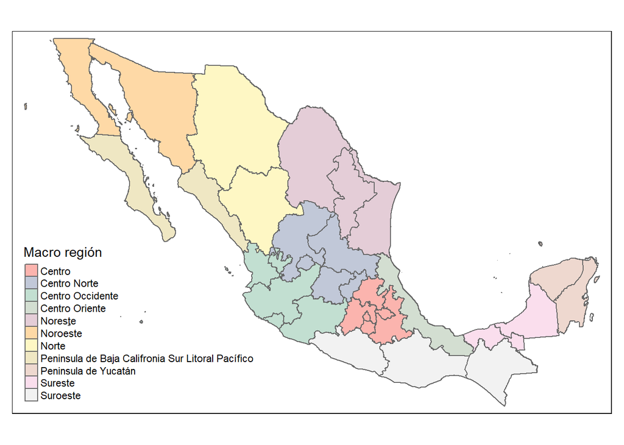

Figura 1. Regionalización en 11 macroregiones

Tabla 2. Distribución porcentual del empleo por macrorregión y cadena productiva

| Macro-región | Metalmecánica | Química | Eléctrico-electrónica | Textiles, confección y prendas de vestir | Construcción | Autotransportes | Papel e impresión | Plásticos y fibras sintéticas | Muebles y productos de madera |
| --- | --- | --- | --- | --- | --- | --- | --- | --- | --- |
| Centro | 59.9 | 60.0 | 51.9 | 62.7 | 31.0 | 59.0 | 37.2 | 90.5 | 54.3 |
| Centro Norte | 1.2 | 1.8 | 0.6 | 0.1 | 1.2 | 1.1 | 2.5 | 0.8 | 2.8 |
| Centro Occidente | 28.2 | 0.1 | 24.8 | 29.6 | 43.2 | 18.7 | 15.0 | 2.2 | 1.2 |
| Centro Oriente | 0.5 | 0.2 | - | - | - | 0.6 | 0.3 | 0.2 | 0.3 |
| Norte | - | 1.5 | 0.1 | - | 1.4 | - | - | 0.2 | - |
| Noreste | 0.3 | 14.9 | 22.1 | 7.0 | 3.3 | 12.7 | 35.1 | 4.8 | 29.7 |
| Noroeste | 8.2 | 18.3 | 0.1 | 0.2 | 18.9 | 4.2 | 8.2 | 0.7 | 7.6 |
| Litoral Pacífico | 1.4 | 2.2 | 0.3 | 0.2 | - | 2.5 | 1.6 | 0.5 | 2.8 |
| Suroeste | - | 0.1 | - | - | 1.0 | 0.1 | - | - | 0.1 |
| Peninsula de Yucatán | 0.3 | 0.9 | 0.1 | 0.1 | - | 0.7 | - | - | 0.5 |
| Sureste | - | - | - | - | - | 0.3 | - | - | 0.7 |
| Suma | 100 | 100 | 100 | 100 | 100 | 100 | 100 | 100 | 100 |

El conjunto de complejos industriales identificados ocupa 1 millón 63 mil 216 personas, que corresponde a cerca de 5.9% del total de personas ocupadas en 2013. La mayor proporción de personal ocupado en todos los complejos industriales se encuentra en la macrorregión Centro, integrada por los estados de Hidalgo, México, Morelos, Puebla, Tlaxcala y la Ciudad de México, excepto en la cadena de la construcción donde la macrorregión Centro occidente (Colima, Jalisco, Michoacán de Ocampo y Nayarit) ocupa la primera posición. Esto es un indicio de que para el año 2013, la preponderancia de los tres grandes centros industriales de México prevalece a pesar de su debilitamiento producto del proceso de apertura neoliberal, pues el Valle de México, Guadalajara y Monterrey, aparecen recurrentemente encabezando la lista de los principales complejos industriales, tal y como en otros estudios se ha verificado (Quintana-Romero and Isaac-Egurrola, 2013) (ver tabla 2).

## 5.1 Los complejos industriales identificados

En seguida, se apuntan algunos de los principales rasgos de los complejos identificados, cadena a cadena.

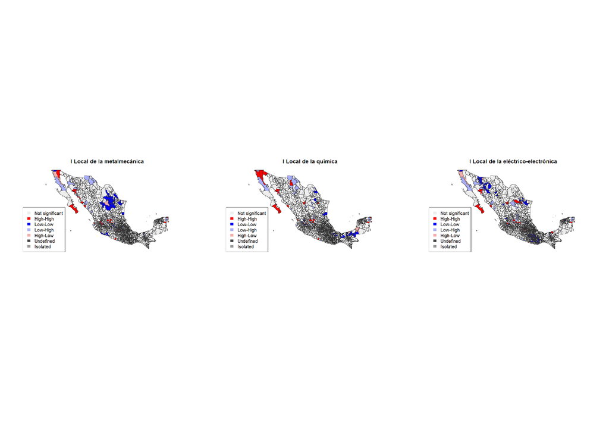

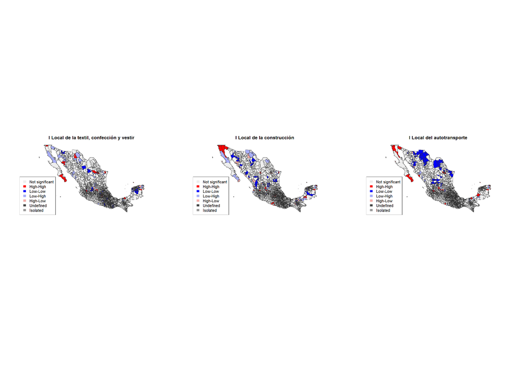

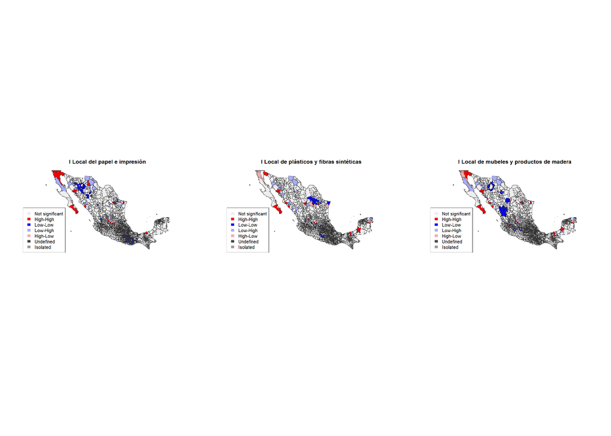

- Metalmecánica

El complejo de la metalmecánica es considerado estratégico en el proceso de industrialización pues “es la que produce la maquinaria y el equipo que requieren los sectores económicos del país productores de bienes y servicios (…). el desarrollo de este sector contribuye sustancialmente a la formación bruta de capital en el país y propicia una menor dependencia con respecto al exterior” (SPyP, 1982, p. iv). Esta cadena está integrada por 22 ramas de actividad, fundamentalmente del sector de la manufactura y los tres principales complejos se encuentran en los Valles de México y Toluca con 33 municipios (58.7% de la ocupación de la cadena), Guadalajara con 7 municipios (27.6%) y Mexicali con sólo un municipio (7.7%).

Además de los municipios que integran los complejos industriales, aquellos que según el índice local de Moran pertenecen a la categoría Alto-Alto, esta cadena presenta 11 municipios identificados en la clasificación de Alto-Bajo, es decir, municipios que tienen un valor alto de la variable de interés pero que están rodeados de otros con valores bajos. Tales municipios son: Ensenada y Playas de Rosarito en Baja California, Parras en Coahuila, San Miguel de Allende, Apaseo el Grande y San José Iturbide en Querétaro, General Zuazua, San Pedro Garza García y Monterrey en Nuevo León, además de Coronango en Puebla y Río Bravo Tamaulipas.

- Química

La naturaleza del proceso de trabajo en esta cadena hace que exista un alto grado de interrelación entre sus actividades, además, una misma empresa o unidad económica puede dedicarse a la fabricación de múltiples valores de uso. La producción de este sector y su comportamiento en el mercado siguen de cerca al conjunto de la actividad económica, debido a su estrecha vinculación y relacionamiento insumo-producto. Los complejos de la cadena productiva de la industria química aparecen en 63 municipios y ocupan a 58 mil 236 personas.

Tres son los complejos más importantes en términos de su ocupación: el del Valle de México (15 municipios y alcaldías) que participa con 59% de la ocupación de la cadena, Mexicali-Tijuana (5 municipios) que participa con 17.9% de las personas ocupadas y Guadalupe-Santiago que con 7 municipios ocupa 14.8% del personal. Además de los complejos anteriormente apuntados, hay un total de 24 municipios con potencial para impulsar crecimiento en los espacios vecinos, fundamentalmente en el occidente de México (Jalisco), el Valle de México y Toluca y el sureste del país en las entidades de Campeche, Tabasco y Veracruz.

- Eléctrico-electrónica

- Textiles, confección y prendas de vestir

Esta histórica cadena productiva, pieza fundamental de la industrialización ligera de México, ha sufrido un continuo declive como resultado del proceso de apertura económica y la entrada de China a la Organización Mundial de Comercio: de ser el cuarto exportador de prendas de vestir en el año 2000, ya en 2012 ocupaba el lugar 17 (Jessica Nájera O., 2016). Esta cadena está integrada por 11 ramas de la actividad económica y el grueso de su ocupación es explicada por el complejo identificado en el Valle de México que con 31 municipios explica 60% de la ocupación de la cadena. Le sigue el complejo de Guadalajara, que con sólo 6 municipios explica casi 30% de la ocupación de la cadena y, finalmente, Monterrey que con 11 municipios explica 7% de la ocupación. Esta cadena tiene 7 municipios que potencialmente podrían contribuir a generar más complejos, fundamentalmente en el estado de Guanajuato en los municipios de Guanajuato, San Felipe y Silao.

- Construcción

Las actividades económicas vinculadas la cadena de la construcción se relacionan con el proceso de desarrollo económico de largo plazo en la medida en que dicha cadena contribuye a la generación de infraestructura. Además, la dinámica de este conjunto de actividades económicas sigue de cerca la dinámica económica agregada por los fuertes vínculos con otras actividades (Rodríguez and García, 2013). La cadena identificada está compuesta por 11 ramas. El complejo industrial más importante es el de Guadalajara, con apenas 6 municipios, que explica más de dos quintas partes de la ocupación de la cadena. El complejo del Valle de México explica prácticamente una tercera parte con 39 municipios y Mexicali, en la frontera con los Estados Unidos, explica 18.9% con sólo 6 municipios. Además, 23 municipios ofrecen potencial para el desarrollo de otros complejos industriales, fundamentalmente en el Litoral Pacífico y en el Sur- Sureste.

- Autotransporte

Las actividades económicas vinculadas a la cadena de autotransporte se han vuelto de las más dinámicas en nuestro país, ampliamente favorecidas por la apertura económica y la atracción de inversión extranjera directa que se ha traducido en el asentamiento de grandes armadoras y la formación, en alguna medida, de redes de proveería (Medina et al., 2014). En el caso de los resultados de este estudio, la cadena de autotransportes está formada por sólo 6 ramas de actividad, de las que destacan la fabricación de automóviles y camiones y la fabricación de partes para vehículos.

El complejo industrial más importante está ubicado en el Valle de México, que concentra 58.2% de la ocupación de la cadena con 28 municipios, seguido del complejo de Guadalajara que con 7 municipios explica 18.3% de la ocupación y Monterrey, con 12.3% de la ocupación en 8 municipios.

De estos resultados destaca que hay algunos municipios importantes por la presencia de esta actividad, como Aguascalientes, Querétaro o León, que no fueron integrados como complejos industriales en la medida en que éstos no han logrado generar un entorno territorial sólidamente integrado, pero constituyen espacios de oportunidad para potenciar los efectos de derrama que dicha cadena tiene en términos territoriales. La actual coyuntura dada por las estrategias de relocalización cercana (el llamado *nearshoring*) de este sector pueden jugar un papel vital en el futuro cercano para tales regiones.

- Papel e impresión

El consumo del papel no ha disminuido con el uso de la comunicación electrónica, por el contrario, se ha incrementado y se ha expandido su uso, a la vez que las empresas ubicadas en esta serie de actividades han buscado ampliar sus fuentes de abastecimiento renovables (José Gerardo Ignacio Gómez Romero et al., 2016). Esta cadena productiva está dirigida, en lo fundamental, el mercado interno y está integrada por 7 ramas de actividad económica.

Los complejos industriales más importantes se encuentran en el Valle de México con 25 municipios que explican 37% de la ocupación de dicha cadena, Monterrey que con 10 municipios concentra el 34.7% de la ocupación y Guadalajara con 7 municipios y 14.9% de la ocupación. Destaca la identificación de Naucalpan de Juárez, en el Estado de México, como un municipio al que el impulso de la política industrial podría traer beneficios a los municipios circundantes y constituirse en un complejo industrial en el sentido usado aquí.

- Plásticos y fibras sintéticas

Este sector, fuertemente vinculado a otros de la manufactura, tuvo en la primera parte del siglo XXI un crecimiento relativamente moderado, aunque por encima de la media nacional (Pérez, 2014). La cadena plástico y fibras sintéticas se integra por sólo 5 ramas de actividad y los complejos industriales más importantes se ubican el Valle de México que, con 25 municipios, contribuye al 89.4% de la ocupación de la cadena, seguido de lejos del complejo ubicado en San Nicolás de los Garza que con 4 municipios explica 4.8%. Municipios con potencial de integrar complejos industriales se encuentran en los estados de Baja California, Coahuila y el Estado de México.

- Muebles

Este conjunto de actividades ha crecido por debajo del conjunto de la manufactura y también ha sido severamente afectado por el proceso de apertura económica (Gomez, 2012). La cadena, integrada por 5 subsectores, tiene sus complejos más importantes también en Valle de México con 18 municipios y una contribución de más de la mitad de la ocupación; Monterrey con 28.8% y 7 municipios y Mexicali que con 2 municipios contribuye el 7.2% de la ocupación. Por otro lado, existen 14 municipios con potencial para generar nuevos complejos industriales, particularmente en el Bajío y en el Valle de México.

## 5.2 Reflexiones finales y posibles rutas de investigación

A lo largo de estas notas ha sido posible identificar 9 cadenas productivas del sector industrial y su ubicación en el territorio nacional a través del concepto de complejos industriales. El método elegido, a diferencia de los trabajos previos, permitió la distinción con una mayor precisión de las unidades territoriales que integran cada complejo. Esto puede ser un elemento que afine las propuestas de política industrial, al incorporar explícitamente la dimensión territorial de la actividad económica, así como los beneficios potenciales de las economías de aglomeración que emergen de tales agrupamientos de actividad.

En las cadenas identificadas es posible apreciar la heterogeneidad estructural que caracteriza a las economías como la Mexicana: sectores con un uso relativamente alto de tecnología e intensidad de capital, como las cadenas eléctrico-electrónica, autotransporte y química, con cadenas más tradicionales como la textil y de la confección o la del mueble. Las cadenas identificadas, principalmente la química y la de la construcción, siguen de cerca los movimientos de la actividad económica agregada, por lo que su impulso influirá en alguna medida en la dinámica económica nacional.

Los resultados indican, en línea con otros estudios (Egurrola and Romero, 2012), que la importancia de los centros industriales ubicados en las grandes metrópolis de México: Valle de México, Valle de Toluca, Guadalajara y Monterrey, seguían siendo hasta 2012 tres de los principales centros de actividad económica industrial de México. Esto lleva a reflexionar sobre la necesidad de integrar, como parte de la política de planeación metropolitana, elementos encaminados al fomento de la transformación e impulso de la actividad industrial asentada para reducir sus impactos en el medio ambiente.

Estos hallazgos son muestra de la necesidad de profundizar en los hallazgos aquí presentados, al menos en dos direcciones: i) estudios detallados de los complejos industriales identificados buscando responder a preguntas relacionadas con los incentivos económicos de localización de las empresas en entornos territoriales específicos, así como una distinción precisa de las características de las empresas ubicadas tanto en los complejos industriales como en espacios susceptibles de impulso, ii) de la mano con lo anterior, incorporar aspectos sociales e institucionales que condicionen o potencien las decisiones de localización de las empresas en dichos complejos. Así pues, estos resultados no son más que un primer paso para un proyecto articulado sobre las condiciones para el desarrollo regional con base industrial.

Pendientes en el código:

- Estimar cada una de las regresiones del empleo total sobre el empleo de cada cadena productiva.
- Añadir los errores de cada regresión a la tabla geográfica.
- Estimar los I de Moran locales y llevarlos a la tabla, junto con los elementos valor del índice y valor p.
- Mapas para cada cadena.
- Identificar a los municipios que integran cada cadena productiva y señalarlos en la base original.
- Identificar la posición que ocupa cada municipio en su contribución a la cadena

Abdi, H., Williams, L.J., 2010. Principal component analysis. Wiley Interdisciplinary Reviews: Computational Statistics 2. https://doi.org/10.1002/wics.101

Adolfsson, A., Ackerman, M., Brownstein, N.C., 2019. To cluster, or not to cluster: An analysis of clusterability methods. Pattern Recognition 88. https://doi.org/10.1016/j.patcog.2018.10.026

Anselin, L., 2020. [Local spatial autocorrelation (2)](https://geodacenter.github.io/workbook/6b_local_adv/lab6b.html#ref-GetisOrd:92). GeoDa Documentation: Workbook.

Anselin, L., 1995. Local indicators of spatial association—LISA. Geographical Analysis 27. https://doi.org/10.1111/j.1538-4632.1995.tb00338.x

Balland, P.A., Boschma, R., Crespo, J., Rigby, D.L., 2019. Smart specialization policy in the european union: Relatedness, knowledge complexity and regional diversification. Regional Studies 53. https://doi.org/10.1080/00343404.2018.1437900

Burgos, R.G., Johnson, J., 2018. Why querétaro? The development of an aeronautical manufacturing cluster in central mexico. Thunderbird International Business Review 60. https://doi.org/10.1002/tie.21844

Castro, B.G., Gallardo, Z.C., 2008. Concentración regional en veracruz. Un enfoque de identificación de aglomeraciones productivas locales. Analisis Económico XXIII.

Castro, M.B.G., Gallardo, Z.C., Enciso, J.A.G., 2009. Localización de arreglos productivos locales (APL). Contribuciones para el análisis regional. Economía y Sociedad XIV.

CEDRUS, 2020. Regiones funcionales de méxico.

Cohen, J.P., Paul, C.J.M., 2009. Agglomeration, productivity and regional growth: Production theory approaches. Handbook of Regional Growth and Development Theories. https://doi.org/10.4337/9781848445987.00013

Cordera, R., Orive, A., 1981. México: Industrialización subordinada. Desarrollo y crisis de la economía mexicana, Lecturas de El Trimestre Económico, México, Fondo de Cultura Económica.

Delgado, M., Porter, M.E., Stern, S., 2016. Defining clusters of related industries. Journal of Economic Geography 16. https://doi.org/10.1093/jeg/lbv017

Duranton, G., 2014. Agglomeration and jobs. Handbook of Regional Science. https://doi.org/10.1007/978-3-662-60723-7_33

Egurrola, J.I., Romero, L.Q., 2012. La industria en la zona metropolitana del valle de méxico. Centro de Estudios para el Desarrollo Alternativo y Plaza y Valdés Editores,.

Feser, E.J., Bergman, E.M., 2000a. National industry cluster templates: A framework for applied regional cluster analysis. Regional Studies 34. https://doi.org/10.1080/00343400050005844

Feser, E.J., Bergman, E.M., 2000b. National industry cluster templates: A framework for applied regional cluster analysis. Regional Studies 34. https://doi.org/10.1080/00343400050005844

Feser, E., Sweeney, S., Renski, H., 2005. A descriptive analysis of discrete u.s. Industrial complexes. Journal of Regional Science 45. https://doi.org/10.1111/j.0022-4146.2005.00376.x

Fischer, M.M., Nijkamp, P., 2014. Handbook of regional science, Handbook of Regional Science. https://doi.org/10.1007/978-3-642-23430-9

Flores, A.D., 2008. Los clusters industriales del noreste de méxico (1993-2003). Perspectivas de desarrollo en el marco de una mayor integración económica con texas. región y sociedad 20. https://doi.org/10.22198/rys.2008.41.a518

Fothergill, S., Gore, T., Wells, P., 2019. Industrial strategy and the UK regions: Sectorally narrow and spatially blind. Cambridge Journal of Regions, Economy and Society 12, 445–466. https://doi.org/10.1093/CJRES/RSZ016

Frenken, K., Oort, F.V., Verburg, T., 2007. Related variety, unrelated variety and regional economic growth. Regional Studies 41. https://doi.org/10.1080/00343400601120296

Gallagher, K.P., Moreno-Brid, J.C., Porzecanski, R., 2008. The dynamism of mexican exports: Lost in (chinese) translation? World Development 36, 1365–1380. https://doi.org/10.1016/j.worlddev.2007.08.004

Gallaud, D., 2013. Encyclopedia of creativity, invention, innovation and entrepreneurship, Encyclopedia of Creativity, Invention, Innovation and Entrepreneurship. https://doi.org/10.1007/978-1-4614-3858-8

Garofoli, G., 2020. Local economic development. International Encyclopedia of Human Geography. https://doi.org/10.1016/B978-0-08-102295-5.10102-7

Getis, A., Ord, J.K., 1992. The analysis of spatial association by use of distance statistics. Geographical Analysis 24. https://doi.org/10.1111/j.1538-4632.1992.tb00261.x

Glaeser, E.L., Kallal, H.D., Scheinkman, J.A., Shleifer, A., 1992. Growth in cities. Journal of Political Economy 100. https://doi.org/10.1086/261856

Gomez, L.E.E., 2012. La industria y el comercio del mueble en méxico. Revista internacional de investigacion en mobiliario y objetos decorativos 1.

Gómez-Zaldívar, M., Mosqueda, M.T., Duran, J.A., 2017. Localization of manufacturing industries and specialization in mexican states: 1993–2013. Regional Science Policy and Practice 9. https://doi.org/10.1111/rsp3.12111

González, A.B.C., 2015. Las zonas industriales de desarrollo y sus encadenamientos productivos. Universidad Nacional Autónoma de México, Facultad de Estudios Superiores Acatlán.

Gordon, I.R., McCann, P., 2000. Industrial clusters: Complexes, agglomeration and/or social networks? Urban Studies 37. https://doi.org/10.1080/0042098002096

INEGI, 2020b. [Censos económicos 2019: metodología](https://www.inegi.org.mx). Instituto Nacional de Estadística y Geografía.

INEGI, 2020a. Marco geoestadístico, censo de población y vivienda 2020 integrado. Instituto Nacional de Estadística y Geografía.

INEGI, 2018a. [Sistema de cuentas nacionales de méxico: Fuentes y metodologías, año base 2013](https://www.inegi.org.mx/contenidos/programas/mip/2013/doc/met_mip.pdf). Instituto Nacional de Estadística y Geografía.

INEGI, 2018b. [Sistema de clasificación industrial de américa del norte, méxico : SCIAN 2018](https://www.inegi.org.mx/contenidos/productos/prod_serv/contenidos/espanol/bvinegi/productos/nueva_estruc/702825099695.pdf). Instituto Nacional de Estadística y Geografía.

Jessica Nájera O., J., 2016. Modelo de competitividad para la industria textil del vestido en méxico. Universidad & Empresa 17. https://doi.org/10.12804/rev.univ.empresa.28.2015.02

Jiménez-Almaguer, K.P., Medina-Quintero, J.-M., Cheín-Schekaibán, N.F., 2013. The search for the development of clusters in tamaulipas, mexico: A case study. Economía: teoría y práctica 39, 89–117.

José Gerardo Ignacio Gómez Romero, J.G.I., Francisco Martín Villarreal Solís, F.M., María Deyanira Villarreal Solís, M.D., 2016. Las incapacidades de aprendizaje organizacional y los estilos de aprendizaje en la industria papelera, cartonera y de celulosa de méxico. Universidad & Empresa 17. https://doi.org/10.12804/rev.univ.empresa.29.2015.02

Komorowski, M., 2020. Identifying industry clusters: A critical analysis of the most commonly used methods. Regional Studies, Regional Science 7. https://doi.org/10.1080/21681376.2020.1733436

Kopczewska, K., Churski, P., Ochojski, A., Polko, A., 2017. Measuring regional specialisation: A new approach, Measuring Regional Specialisation: A New Approach. Springer International Publishing. https://doi.org/10.1007/978-3-319-51505-2

Laguna-Reyes, C.E., 2010. Cadenas productivas, columna vertebral de los clusters industriales mexicanos. Economía Mexicana, Nueva Época 19, 119–170.

López-Hernández, C.E., 2018. Historia del clúster de calzado en jalisco y su impacto en la estructura industrial. Revista Perspectiva Empresarial 5, 69–77. https://doi.org/10.16967/rpe.v5n1a6

Marshall, A., 1957. Principios de economía.

Martin, R., Sunley, P., 2003. Deconstructing clusters: Chaotic concept or policy panacea? Journal of Economic Geography 3. https://doi.org/10.1093/jeg/3.1.5

Marx, K., 2011. El capital : Crítica de la economía política, El capital. Crítica de la Economía Política. Siglo XXI.

Medina, L.Á., Carrillo, J., Gonzales, M., 2014. El auge de la industria automotriz en méxico en el siglo XXI: Reestructuración y catching up, Unam. Publicaciones Empresariales, UNAM, FCA.

Mendoza-Velazquez, A., 2017. The effect of industrial competition on employment: A porter’s approach to the study of industrial clusters in mexico. Competitiveness Review 27. https://doi.org/10.1108/CR-02-2016-0011

Moreno-Brid, J.C., Ros-Bosch, J., 2018. Desarrollo y crecimiento en la economía mexicana: Una perspectiva histórica. Fondo de Cultura Económica.

Nieto, A.B.T., Negrete, M.E., 2018b. Dinámicas productivas y agrupamientos industriales en la región centro de méxico. región y sociedad 30. https://doi.org/10.22198/rys.2018.73.a905

Nieto, A.B.T., Negrete, M.E., 2018a. Dinámicas productivas y agrupamientos industriales en la región centro de méxico. región y sociedad 30. https://doi.org/10.22198/rys.2018.73.a905

O’Donoghue, D., Gleave, B., 2004. A note on methods for measuring industrial agglomeration. Regional Studies 38. https://doi.org/10.1080/03434002000213932

Oort, F.G. van, Lambooy, J.G., 2014. Cities, knowledge, and innovation. Handbook of Regional Science. https://doi.org/10.1007/978-3-642-23430-9_27

Pacheco-Vega, R., 2007. Una crítica al paradigma de desarrollo regional mediante clusters industriales forzados. Estudios Sociológicos XXV.

Palma, G., 2005. Cuatro fuentes de "desindustrialización" y un nuevo concepto del "síndrome holandés". Más allá de las reformas: dinámica estructural y vulnerabilidad macroeconómica.

Pérez, J.P.G., 2014. La industria del plástico en méxico y el mundo. Comercio Exterior 64.

Quintana-Romero, L., Isaac-Egurrola, J., 2013. Industria y vaciamiento productivo regional en méxico. Desarrollo regional y urbano. Análisis estratégico para el desarrollo.

Rabellotti, R., 1995. Is there an "industrial district model"? Footwear districts in italy and mexico compared. World Development 23. https://doi.org/10.1016/0305-750X(94)00103-6

Rodríguez, J.R., García, L.V., 2013. Estructura y desempeño del sector de la construcción en méxico. El Cotidiano Noviembre-Diciembre.

Scott, A.J., 2006. Geography and Economy: Three Lectures. Oxford University Press. https://doi.org/10.1093/oso/9780199284306.001.0001

Secretaría_de_Economía, 2022. [Rumbo a una política industrial](https://www.gob.mx/cms/uploads/attachment/file/761984/Rumbo_a_una_Pol_tica_Industrial.pdf). Gobierno de México.

Sjöholm, F., 1999. Productivity growth in indonesia: The role of regional characteristics and direct foreign investment. Economic Development and Cultural Change 47. https://doi.org/10.1086/452419

Sonis, M., Hewings, G.J.D., Guo, D., 2008. Industrial clusters in the input-output economic system. Handbook of Research on Cluster Theory. https://doi.org/10.4337/9781848442849.00016

SPyP, 1982. La industria metalmecánica y de bienes de capital en méxico. Coordinación General de los Servicios Nacionales de Estadística, Geografía e Informática. Secretaría de Programación y Presupuesto (SPyP). Secretaría de Programación y Presupuesto, Coordinación General de los Servicios Nacionales de Estadística, Geografía e Informática.

Szirmai, A., 2012. Industrialisation as an engine of growth in developing countries, 1950-2005. Structural Change and Economic Dynamics 23. https://doi.org/10.1016/j.strueco.2011.01.005

Trejo, A., 2017. Crecimiento económico e industrialización en la agenda 2030: Perspectivas para méxico. Problemas del Desarrollo 48. https://doi.org/10.1016/j.rpd.2017.01.005

Trejo-Nieto, B.A., 2013. The geographic concentration in mexican manufacturing industries, an account of patterns, dynamics and explanations: 1988-2003. Investigaciones Regionales 18, 13–60.

Trippl, M., Bergman, E.M., 2021. Clusters, local districts, and innovative milieux. Handbook of Regional Science. https://doi.org/10.1007/978-3-662-60723-7_26

Tvaronavičienė, M., Razminienė, K., Piccinetti, L., 2015. Aproaches towards cluster analysis. Economics and Sociology 8. https://doi.org/10.14254/2071-789X.2015/8-1/2

Viana, E.N.A., 2012. [El sector eléctrico y electrónico en méxico](http://galeon.hispavista.com/electroa2/img/electrodomesticos.jpg). Comercio Exterior Julio-Agosto.

Villarreal, A.G., Mack, E.A., Flores, M., 2017. Industrial complexes in mexico: Implications for regional industrial policy based on related variety and smart specialization. Regional Studies 51. https://doi.org/10.1080/00343404.2015.1114174

[^1]: Una exposición más detallada de esta consideración puede consultarse en Feser et al.(2005).